# Group 8: Hotel Bookings

Alex Armstrong, Si Chen, Ethan Lamons

10/16/2020

# Introduction

For this project, we used the Hotel Bookings dataset from the Tidy Tuesday R repository. Each of us took different variables and analyzed the relationships between these variables using various statistical analysis tools and graphs. The first section by Ethan Lamons compares the average daily rate (ADR) per booking with the amount and age range of the party that booked the room. A further comparison is made between the ADR and the number of kids per booking party with a linear regression analysis made for each comparison. For the second section, Si Chen provides data visualization in the room reservations by type. She also conducted two linear regression analysis in finding the relationship between nights stayed at hotels on weekdays or weekends and having children or babies. For the third section, Alex Armstrong looked at the country data. Firstly with the mean average daily rate per country, then the mean lead time per country. After that, a further comparison was made between the distribution channel and the lead time. An analysis of variance was then made between the 3 main distribution channels and their lead times.

Loading all of the packages needed.

```r
install.packages("tidytuesdayR", repos = "http://cran.us.r-project.org")
library(tidytuesdayR)
library(tidyverse)
library(outliers)
library(ggdark)
install.packages("rworldmap", repos = "http://cran.us.r-project.org")
library(rworldmap)
install.packages("RColorBrewer", repos = "http://cran.us.r-project.org")
library(RColorBrewer)
```

# Part 1: Analysis Between adr and Booking Party Composition

There are two comparisons done in this section. One is between adr and the full party composition with the colors showing the breakdown of the party by age group.

The other is between adr and the number of kids. A linear regression analysis is shown at the end, and the resulting line.

## 1.1 Bringing in and modifying the dataset

First thing is to bring in the Hotel Bookings data from the Tidy Tuesday repository.

```r
hotels <- readr::read_csv('https://raw.githubusercontent.com/rfordatascience/tidytuesday/master/data/2020/2020-02-11/hotels.csv')
hotels
```

```
## # A tibble: 119,390 x 32
##    hotel is_canceled lead_time arrival_date_ye~ arrival_date_mo~
##    <chr>       <dbl>     <dbl>            <dbl> <chr>
##  1 Reso~           0       342             2015 July
##  2 Reso~           0       737             2015 July
##  3 Reso~           0         7             2015 July
##  4 Reso~           0        13             2015 July
##  5 Reso~           0        14             2015 July
##  6 Reso~           0        14             2015 July
##  7 Reso~           0         0             2015 July
##  8 Reso~           0         9             2015 July
##  9 Reso~           1        85             2015 July
## 10 Reso~           1        75             2015 July
## # ... with 119,380 more rows, and 27 more variables:
## #   arrival_date_week_number <dbl>, arrival_date_day_of_month <dbl>,
## #   stays_in_weekend_nights <dbl>, stays_in_week_nights <dbl>, adults <dbl>,
## #   children <dbl>, babies <dbl>, meal <chr>, country <chr>,
## #   market_segment <chr>, distribution_channel <chr>, is_repeated_guest <dbl>,
## #   previous_cancellations <dbl>, previous_bookings_not_canceled <dbl>,
## #   reserved_room_type <chr>, assigned_room_type <chr>, booking_changes <dbl>,
## #   deposit_type <chr>, agent <chr>, company <chr>, days_in_waiting_list <dbl>,
## #   customer_type <chr>, adr <dbl>, required_car_parking_spaces <dbl>,
## #   total_of_special_requests <dbl>, reservation_status <chr>,
## #   reservation_status_date <date>
```

Next thing is to modify the dataset to choose only the needed variables for the graphs and analysis. I also removed outliers and added in two new variables, “Number_of_Kids_per_Party” and “party_size”. The way I determined the outliers is shown below. I also removed any adr and party_size values that equaled zero since that data is irrelevant to my analysis.

```r
adr_by_party <- hotels %>%
  select(adults, children, babies, adr) %>%
  mutate(party_size = (adults + children + babies)) %>%
  mutate(Number_of_Kids_per_Party = (children + babies)) %>%
  arrange(party_size) %>%
  filter(adr < 500 & adr != 0 & party_size < 10 & party_size > 0) %>%
  na.omit(adr_by_party)
```

```r
summary(adr_by_party)
```

```
##      adults         children          babies              adr
##  Min.   :0.000   Min.   :0.0000   Min.   :0.000000   Min.   : -6.38
##  1st Qu.:2.000   1st Qu.:0.0000   1st Qu.:0.000000   1st Qu.: 70.53
##  Median :2.000   Median :0.0000   Median :0.000000   Median : 95.00
##  Mean   :1.861   Mean   :0.1045   Mean   :0.007709   Mean   :103.49
##  3rd Qu.:2.000   3rd Qu.:0.0000   3rd Qu.:0.000000   3rd Qu.:126.00
##  Max.   :4.000   Max.   :3.0000   Max.   :2.000000   Max.   :451.50
##    party_size    Number_of_Kids_per_Party
##  Min.   :1.000   Min.   :0.0000
##  1st Qu.:2.000   1st Qu.:0.0000
##  Median :2.000   Median :0.0000
##  Mean   :1.973   Mean   :0.1122
##  3rd Qu.:2.000   3rd Qu.:0.0000
##  Max.   :5.000   Max.   :3.0000
```

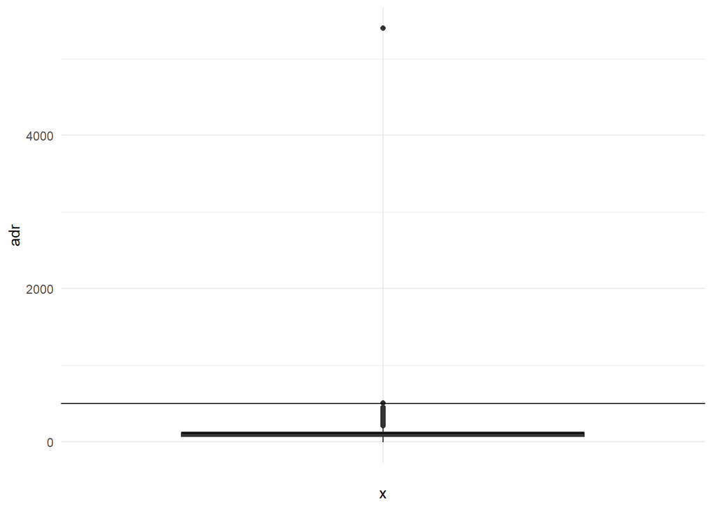

```r
ggplot(hotels) +
  aes(x = "", y = adr) +
  geom_boxplot(fill = "#000000") +
  theme_minimal() +
  geom_hline(aes(yintercept = 500), colour = "black")
```

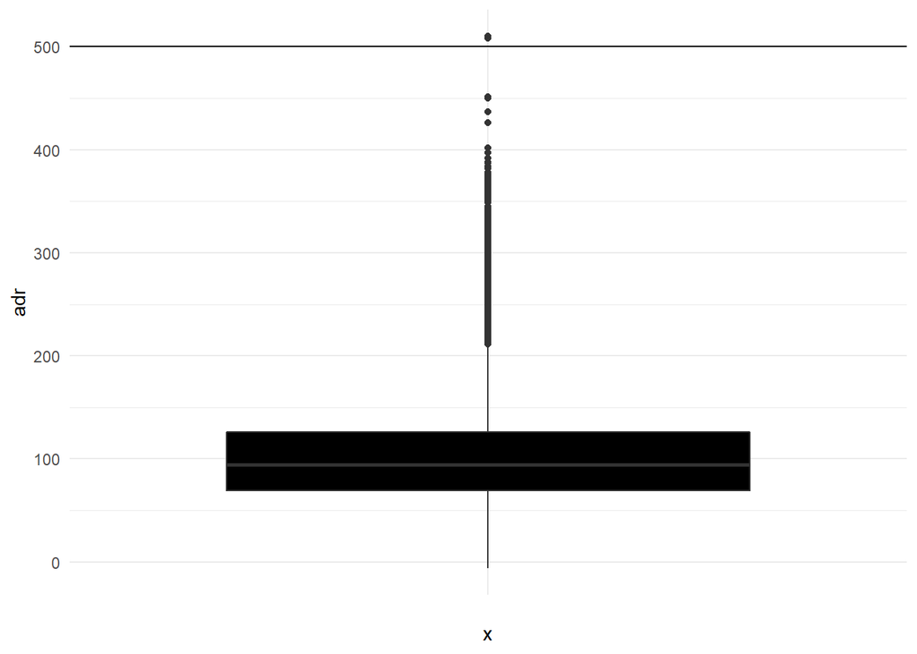

```r
hotels %>%
  filter(adr >= -50L & adr <= 1300L) %>%
  ggplot() +
  aes(x = "", y = adr) +
  geom_boxplot(fill = "#000000") +
  theme_minimal() +
  geom_hline(aes(yintercept = 500), colour = "black")
```

## 1.2 Making a graph showing relation between number of people per booking and adr

Below is a tile graph showing the relationship between the number of people per booking and adr. The colors on the graph show the number of kids per party. The white line is the result of a linear regression analysis shown in a later section. From the graph, there is a significant correlation between party size and adr with a further correlation between adr and the number of kids per party. This result lead to the next graph. A full image .png of the graph is available under the Figures folder in the repository.

```
## Inverted geom defaults of fill and color/colour.
## To change them back, use invert_geom_defaults().
```

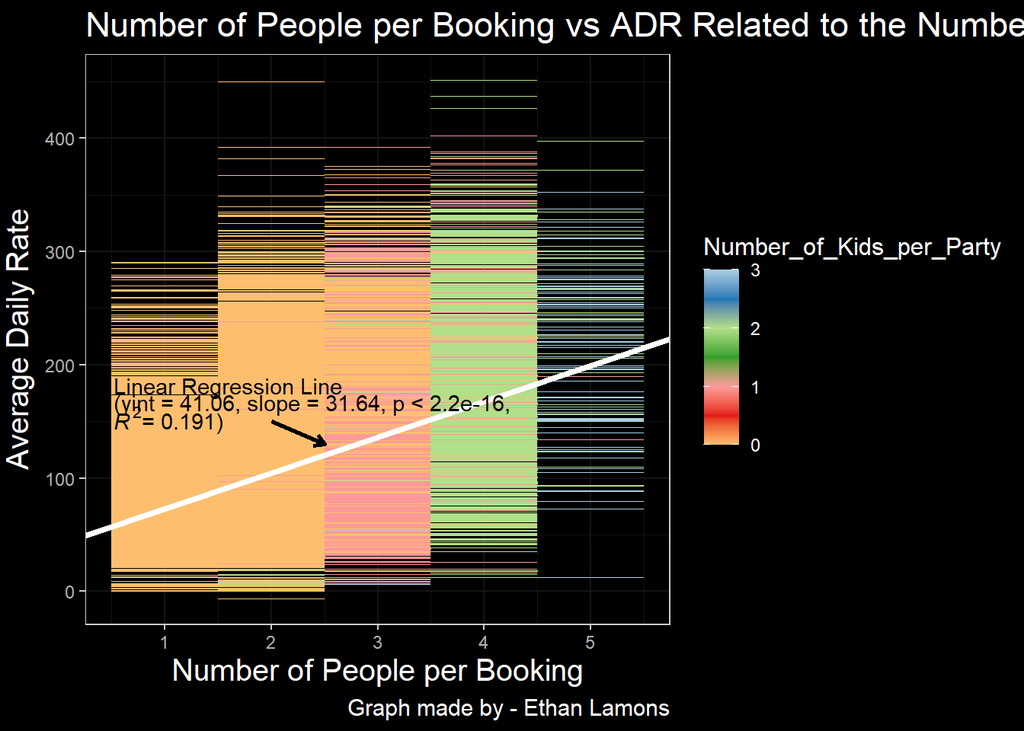

```r
(npeople_v_adr_plot <- ggplot(adr_by_party) +
  aes(x = party_size, y = adr, colour = Number_of_Kids_per_Party) +
  geom_tile() +
  scale_color_distiller(palette = "Paired") +
  labs(x = "Number of People per Booking", y = "Average Daily Rate", title = "Number of People per Booking vs ADR Related to the Number of Kids per Party", caption = "Graph made by - Ethan Lamons") +
  dark_theme_bw() +
  theme(axis.title.x = element_text(size = 15),
        axis.title.y = element_text(size = 15, vjust = 2),
        title = element_text(size = 14),
        legend.title = element_text(size = 12)) +
  geom_abline(aes(slope = 31.64, intercept = 41.06), size = 1.5) +
  scale_x_continuous(n.break = 6) +
  annotate(geom = "segment", x = 2, y = 150, xend = 2.5, yend = 130, size = 1, colour = "black", arrow = arrow(length = unit(2, "mm"))) +
  annotate(geom = "text", x = 0.52, y = 182, label = "Linear Regression Line", hjust = "left", colour = "black") +
  annotate(geom = "text", x = 0.52, y = 167, label = "(yint = 41.06, slope = 31.64, p < 2.2e-16,", hjust = "left", colour = "black") +
  annotate(geom = "text", x = 0.52, y = 152, label = "paste(italic(R) ^ 2, \"= 0.191)\")", parse = TRUE, hjust = "left", colour = "black"))
```

## 1.3 Graph showing the relation between the number of kids per party and adr

This graph is similar to the previous except the x axis variable is the number of kids per booking, and the colors are there to make it easier to distinguish the columns. Again, the white line is from a linear regression analysis shown below. A full size .png of the graph can be found in the Figures folder.

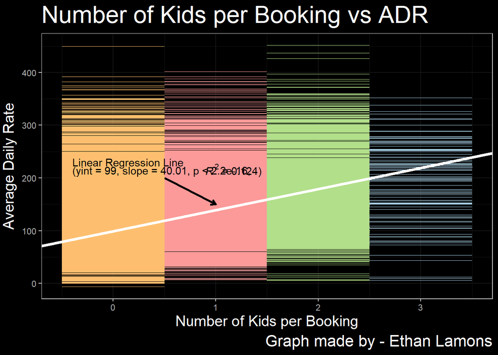

```r
(nkids_v_adr <- ggplot(adr_by_party) +
  aes(x = Number_of_Kids_per_Party , y = adr, colour = Number_of_Kids_per_Party) +
  geom_tile(show.legend = FALSE) +
  scale_color_distiller(palette = "Paired") +
  labs(x = "Number of Kids per Booking", y = "Average Daily Rate", title = "Number of Kids per Booking vs ADR", caption = "Graph made by - Ethan Lamons") +
  dark_theme_bw() +
  geom_abline(slope = 40.01, intercept = 99, size = 1.5) +
  scale_x_continuous(n.break = 6) +
  theme(axis.title.x = element_text(size = 15),
        axis.title.y = element_text(size = 15, vjust = 2),
        title = element_text(size = 20)) +
  annotate(geom = "segment", x = 0.5, y = 200, xend = 1, yend = 150, size = 1, colour = "black", arrow = arrow(length = unit(2, "mm"))) +
  annotate(geom = "text", x = -.4, y = 230, label = "Linear Regression Line", hjust = "left", colour = "black") +
  annotate(geom = "text", x = -.4, y = 215, label = "(yint = 99, slope = 40.01, p < 2.2e-16,", hjust = "left", colour = "black") +
  annotate(geom = "text", x = 0.9, y = 215, label = "paste(italic(R) ^ 2, \" = 0.124)\")", parse = TRUE, hjust = "left", colour = "black"))
```

## 1.4 Linear regression analysis of the data

The linear regression lines found on each of the graphs come from the analysis shown below. First is making the linear regression variable for each comparison and then showing the summary of the linear regression values. Both graphs show a very high significance between the variables used which comes from the low p-value. The R-squared value is low, though, showing that the correlation is not very strong.

```r
#Corresponding to the first graph
lm.party_size <- lm(adr_by_party$adr ~ adr_by_party$party_size)
#Corresponding to the second graph
lm.nkids <- lm(adr_by_party$adr ~ adr_by_party$Number_of_Kids_per_Party)
```

```r
#Corresponding to the first graph
summary(lm.party_size)
```

```
##
## Call:
## lm(formula = adr_by_party$adr ~ adr_by_party$party_size)
##
## Residuals:
##     Min      1Q  Median      3Q     Max
## -187.25  -29.34   -5.70   22.30  345.66
##
## Coefficients:
##                         Estimate Std. Error t value Pr(>|t|)
## (Intercept)              41.0615     0.3945   104.1   <2e-16 ***
## adr_by_party$party_size  31.6377     0.1900   166.5   <2e-16 ***
## ---
## Signif. codes:  0 '***' 0.001 '**' 0.01 '*' 0.05 '.' 0.1 ' ' 1
##
## Residual standard error: 41.98 on 117388 degrees of freedom
## Multiple R-squared:  0.1911, Adjusted R-squared:  0.191
## F-statistic: 2.772e+04 on 1 and 117388 DF,  p-value: < 2.2e-16
```

```r
#Corresponding to the second graph
summary(lm.nkids)
```

```
##
## Call:
## lm(formula = adr_by_party$adr ~ adr_by_party$Number_of_Kids_per_Party)
##
## Residuals:
##     Min      1Q  Median      3Q     Max
## -213.03  -31.00   -7.06   22.00  351.00
##
## Coefficients:
##                                       Estimate Std. Error t value Pr(>|t|)
## (Intercept)                            99.0041     0.1322   749.1   <2e-16 ***
## adr_by_party$Number_of_Kids_per_Party  40.0088     0.3104   128.9   <2e-16 ***
## ---
## Signif. codes:  0 '***' 0.001 '**' 0.01 '*' 0.05 '.' 0.1 ' ' 1
##
## Residual standard error: 43.68 on 117388 degrees of freedom
## Multiple R-squared:  0.124,  Adjusted R-squared:  0.124
## F-statistic: 1.661e+04 on 1 and 117388 DF,  p-value: < 2.2e-16
```

## 1.5 Creating a .txt file with the means

Finally, I created a text file that contains all the means of the variables I used. The file can be found in the Data folder.

```r
means_adr_by_party <- as.data.frame(lapply(adr_by_party, mean), row.names = "mean")
write.table(means_adr_by_party, file = "C:/Users/lamon/Desktop/CPSC441/Group_8/Data/adr_by_party_means.txt")
```

# PART 2: Analysis of Room Reserved and Nights stayed

## 2.1

Assigning a variable that contains the number of counts by unique room types in reserved room type and showing the counts.

```r
library(dplyr)
room_reservation_preference<-hotels%>%
            count(reserved_room_type)
room_reservation_preference
```

```
## # A tibble: 10 x 2
##    reserved_room_type     n
##    <chr>              <int>
##  1 A                  85994
##  2 B                   1118
##  3 C                    932
##  4 D                  19201
##  5 E                   6535
##  6 F                   2897
##  7 G                   2094
##  8 H                    601
##  9 L                      6
## 10 P                     12
```

## 2.2

Making a graph out of the value counts. From the graph, we can see that the room type A is the abusolute most reserved room type, with 85994 reservations. The type of room is not specified but I suppose room type A is the standard room.

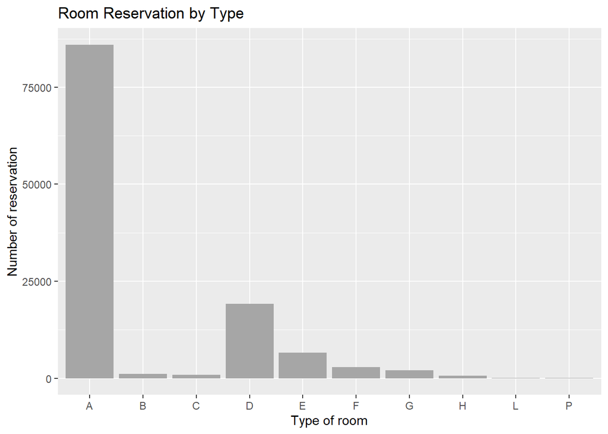

```r
library(ggplot2)
room_type<- as_tibble(room_reservation_preference)
room_reservation_plot<-ggplot(room_type,mapping=aes(x=room_type$reserved_room_type, y=room_type$n))+
      geom_bar(stat = "identity")+
      labs(x="Type of room",y="Number of reservation")+
      ggtitle("Room Reservation by Type")

room_reservation_plot
```

```r
ggsave(room_reservation_plot,device="pdf")
```

## 2.3

Conducting two linear regressions First, we want to know whether families with children or babies stay more nights on week days Second, we want to know whtehr families with children or babies stay more nights on weekend days

```r
lm.week_day_stays <- lm(hotels$stays_in_week_nights ~ hotels$children+hotels$babies)
lm.weekend_day_stays <- lm(hotels$stays_in_weekend_nights ~ hotels$children+ hotels$babies)
```

Outputting summaries for the two regressions We can see from the regression results that both children and babies are very significant in explaining the dependent variables that are weekday stays and weekend stays. However, both adjusted R-squared are very low. This suggests that whether having children or babies can not explain much of the variance in nights staying on weekdays or weekends.

```r
summary(lm.week_day_stays )
```

```
##
## Call:
## lm(formula = hotels$stays_in_week_nights ~ hotels$children +
##     hotels$babies)
##
## Residuals:
##    Min     1Q Median     3Q    Max
## -4.849 -1.476 -0.476  0.524 47.524
##
## Coefficients:
##                 Estimate Std. Error t value Pr(>|t|)
## (Intercept)     2.475572   0.005716 433.095  < 2e-16 ***
## hotels$children 0.209439   0.013845  15.127  < 2e-16 ***
## hotels$babies   0.374847   0.056633   6.619 3.63e-11 ***
## ---
## Signif. codes:  0 '***' 0.001 '**' 0.01 '*' 0.05 '.' 0.1 ' ' 1
##
## Residual standard error: 1.906 on 119383 degrees of freedom
##   (4 observations deleted due to missingness)
## Multiple R-squared:  0.00232,    Adjusted R-squared:  0.002303
## F-statistic: 138.8 on 2 and 119383 DF,  p-value: < 2.2e-16
```

```r
summary(lm.weekend_day_stays )
```

```
##
## Call:
## lm(formula = hotels$stays_in_weekend_nights ~ hotels$children +
##     hotels$babies)
##
## Residuals:
##     Min      1Q  Median      3Q     Max
## -2.6969 -0.9144  0.0856  1.0856 18.0856
##
## Coefficients:
##                 Estimate Std. Error t value Pr(>|t|)
## (Intercept)     0.914376   0.002991 305.699  < 2e-16 ***
## hotels$children 0.113690   0.007245  15.692  < 2e-16 ***
## hotels$babies   0.178249   0.029635   6.015 1.81e-09 ***
## ---
## Signif. codes:  0 '***' 0.001 '**' 0.01 '*' 0.05 '.' 0.1 ' ' 1
##
## Residual standard error: 0.9974 on 119383 degrees of freedom
##   (4 observations deleted due to missingness)
## Multiple R-squared:  0.002399,   Adjusted R-squared:  0.002383
## F-statistic: 143.6 on 2 and 119383 DF,  p-value: < 2.2e-16
```

## 2.4

Saving the means of variables I used to a text file

```r
means_hotel_stays <- hotels%>%
   select(reserved_room_type,stays_in_week_nights,stays_in_weekend_nights,children,babies)%>%
   na.omit(means_hotel_stays)
means_hotel_stays <- as.data.frame(lapply(means_hotel_stays, mean), row.names = "mean")
write.table(means_hotel_stays, file = "hotel_stays_means.txt")
```

# PART 3: Countries / Lead Time - Alex:

I was initially interested in the country by country data, which is difficult to visualize with a simple graph as there are hundreds of countries in the data-set, so I used the ‘rworldmap’ package. The hotels data set includes the country data in the form of iso3 country codes, which allows the hotel data to be joined to the correct country on the world map. Visualizing the data in map form allows us to see that the average daily rate (defined by dividing the sum of all lodging transactions by the total number of staying nights within a country) appears to be higher in the U.S. and other countries such as Kazakhstan. First, I had to manipulate the data by using group_by to group the data for each country. Then I took the mean of the average daily rate for each country.

```r
by_country <- hotels %>%
  group_by(country) %>%
  summarise(mean_adr=mean(adr))
print(by_country)
```

```
## # A tibble: 178 x 2
##    country mean_adr
##    <chr>      <dbl>
##  1 ABW        128.
##  2 AGO        117.
##  3 AIA        265
##  4 ALB         84.4
##  5 AND        203.
##  6 ARE        136.
##  7 ARG        118.
##  8 ARM        100.
##  9 ASM         72.1
## 10 ATA        134.
## # ... with 168 more rows
```

```r
mapped_data <- joinCountryData2Map(by_country,
        joinCode = "ISO3",
        nameJoinColumn = "country")
```

```
## 171 codes from your data successfully matched countries in the map
## 7 codes from your data failed to match with a country code in the map
## 72 codes from the map weren't represented in your data
```

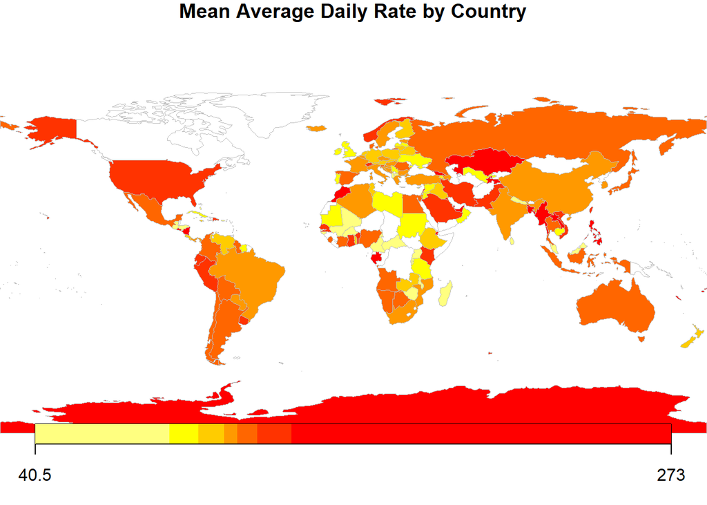

```r
par(mai=c(0,0,0.2,0), xaxs = "i", yaxs = "i")
mapParams <- mapCountryData(mapped_data,
        nameColumnToPlot = "mean_adr",
        mapTitle = "Mean Average Daily Rate by Country",
        addLegend=F)
do.call(addMapLegend,
        c(mapParams,
          legendLabels='limits',
          legendWidth=1.0,
          legendIntervals='data'
          ))
```

Using the same tools, I started looking into the Lead Time data, which states how far in advance bookings are made. Once again I used the ‘rworldmap’ package. This time I made a legend box, which shows the categories of the data much better.  
I manually created the bounds for the legend. I also used a different colour scheme using the RColorBrewer package.

```r
by_country2 <- hotels %>%
  group_by(country) %>%
  summarise(mean_leadtime=mean(lead_time))
```

```r
colourPalette2 <- brewer.pal(n=7,name='RdPu')
mapped_data2 <- joinCountryData2Map(by_country2,
        joinCode = "ISO3",
        nameJoinColumn = "country")
```

```
## 171 codes from your data successfully matched countries in the map
## 7 codes from your data failed to match with a country code in the map
## 72 codes from the map weren't represented in your data
```

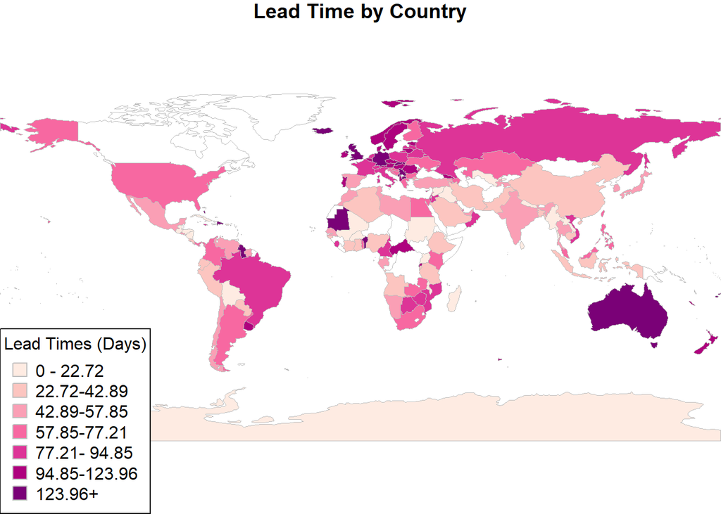

```r
par(mai=c(0,0,0.2,0), xaxs = "i", yaxs = "i")
mapParams2 <- mapCountryData(mapped_data2,
        nameColumnToPlot = "mean_leadtime",
        mapTitle = "Lead Time by Country",
        colourPalette = colourPalette2,
        addLegend = F)
mapParams2$legendText <-
  c('0 - 22.72',
    '22.72-42.89',
    '42.89-57.85',
    '57.85-77.21',
    '77.21- 94.85',
    '94.85-123.96',
    '123.96+')
do.call(addMapLegendBoxes,
        c(mapParams2,
          title='Lead Times (Days)'))
```

Further exploring the lead time variable showed there appeared to be a difference in lead time depending on the distribution method. To measure this, I created a bar plot. This time it shows the average lead time within different distribution channels. First I grouped by distribution channel again and then caluclated the mean and standard devaitions for each distribution channel.

```r
by_distribution_channel<-hotels %>%
  group_by(distribution_channel) %>%
  summarise(mean_dist_leadtime=mean(lead_time),
            sd_dist_leadtime=sd(lead_time))
```